# Did the introduction of streaming services cause a decrease in box office revenue?

This notebook contains the causal inference section of the project

```r
install.packages('rdrobust')
library(tidyverse)
library(lubridate)
library(rdrobust)
```

```r
box_office_data <- read.csv("cleaned_box_office_2024.csv")
print(head(box_office_data))
```

```
  Rank X.Worldwide X.Domestic Domestic.. X.Foreign Foreign..                       Genres Release_Date                          Title
1    1   546388108  215409889       39.4 330978219      60.6  Adventure, Action, Thriller   2000-05-24         Mission: Impossible II
2    2   460583960  187705427       40.8 272878533      59.2     Action, Drama, Adventure   2000-05-01                      Gladiator
3    3   429632142  233632142       54.4 196000000      45.6             Adventure, Drama   2000-12-22                      Cast Away
4    4   374111707  182811707       48.9 191300000      51.1              Comedy, Romance   2000-12-15                What Women Want
5    5   349822765  137748063       39.4 212074702      60.6 Animation, Family, Adventure   2000-05-19                       Dinosaur
6    6   345842198  260745620       75.4  85096578      24.6      Family, Comedy, Fantasy   2000-11-17 How the Grinch Stole Christmas
  Popularity Adventure    Action  Thriller     Drama    Comedy   Romance Animation    Family   Fantasy Horror Mystery Crime History War
1     39.663 546388108 546388108 546388108         0         0         0         0         0         0      0       0     0       0   0
2     58.099 460583960 460583960         0 460583960         0         0         0         0         0      0       0     0       0   0
3     43.596 429632142         0         0 429632142         0         0         0         0         0      0       0     0       0   0
4     30.686         0         0         0         0 374111707 374111707         0         0         0      0       0     0       0   0
5     85.838 349822765         0         0         0         0         0 349822765 349822765         0      0       0     0       0   0
6     79.937         0         0         0         0 345842198         0         0 345842198 345842198      0       0     0       0   0
  Science.Fiction Music Western Documentary TV.Movie
1               0     0       0           0        0
2               0     0       0           0        0
3               0     0       0           0        0
4               0     0       0           0        0
5               0     0       0           0        0
6               0     0       0           0        0
```

```r
print(str(box_office_data))
```

```
'data.frame':   2883 obs. of  29 variables:
 $ Rank           : int  1 2 3 4 5 6 7 8 10 11 ...
 $ X.Worldwide    : num  5.46e+08 4.61e+08 4.30e+08 3.74e+08 3.50e+08 ...
 $ X.Domestic     : num  2.15e+08 1.88e+08 2.34e+08 1.83e+08 1.38e+08 ...
 $ Domestic..     : num  39.4 40.8 54.4 48.9 39.4 75.4 50.3 55.6 53.3 56.5 ...
 $ X.Foreign      : num  3.31e+08 2.73e+08 1.96e+08 1.91e+08 2.12e+08 ...
 $ Foreign..      : num  60.6 59.2 45.6 51.1 60.6 24.6 49.7 44.4 46.7 43.5 ...
 $ Genres         : chr  "Adventure, Action, Thriller" "Action, Drama, Adventure" "Adventure, Drama" "Comedy, Romance" ...
 $ Release_Date   : chr  "2000-05-24" "2000-05-01" "2000-12-22" "2000-12-15" ...
 $ Title          : chr  "Mission: Impossible II" "Gladiator" "Cast Away" "What Women Want" ...
 $ Popularity     : num  39.7 58.1 43.6 30.7 85.8 ...
 $ Adventure      : num  5.46e+08 4.61e+08 4.30e+08 0.00 3.50e+08 ...
 $ Action         : num  5.46e+08 4.61e+08 0.00 0.00 0.00 ...
 $ Thriller       : num  5.46e+08 0.00 0.00 0.00 0.00 ...
 $ Drama          : num  0.00 4.61e+08 4.30e+08 0.00 0.00 ...
```

[output cut: 16 more lines]

Based on the EDA performed in Jupyter notebook the cut off point was chosen to be 2012, this has been judged to be the approximate year that streaming services started to become popular. As shown in the EDA the popularity of streaming services has increased over time so the expected effect of a drop in box office revenue may not be instant.

```r
box_office_data$Release_Date <- ymd(box_office_data$Release_Date)
print(str(box_office_data))
```

```
'data.frame':   2883 obs. of  29 variables:
 $ Rank           : int  1 2 3 4 5 6 7 8 10 11 ...
 $ X.Worldwide    : num  5.46e+08 4.61e+08 4.30e+08 3.74e+08 3.50e+08 ...
 $ X.Domestic     : num  2.15e+08 1.88e+08 2.34e+08 1.83e+08 1.38e+08 ...
 $ Domestic..     : num  39.4 40.8 54.4 48.9 39.4 75.4 50.3 55.6 53.3 56.5 ...
 $ X.Foreign      : num  3.31e+08 2.73e+08 1.96e+08 1.91e+08 2.12e+08 ...
 $ Foreign..      : num  60.6 59.2 45.6 51.1 60.6 24.6 49.7 44.4 46.7 43.5 ...
 $ Genres         : chr  "Adventure, Action, Thriller" "Action, Drama, Adventure" "Adventure, Drama" "Comedy, Romance" ...
 $ Release_Date   : Date, format: "2000-05-24" "2000-05-01" "2000-12-22" "2000-12-15" ...
 $ Title          : chr  "Mission: Impossible II" "Gladiator" "Cast Away" "What Women Want" ...
 $ Popularity     : num  39.7 58.1 43.6 30.7 85.8 ...
 $ Adventure      : num  5.46e+08 4.61e+08 4.30e+08 0.00 3.50e+08 ...
 $ Action         : num  5.46e+08 4.61e+08 0.00 0.00 0.00 ...
 $ Thriller       : num  5.46e+08 0.00 0.00 0.00 0.00 ...
 $ Drama          : num  0.00 4.61e+08 4.30e+08 0.00 0.00 ...
```

[output cut: 16 more lines]

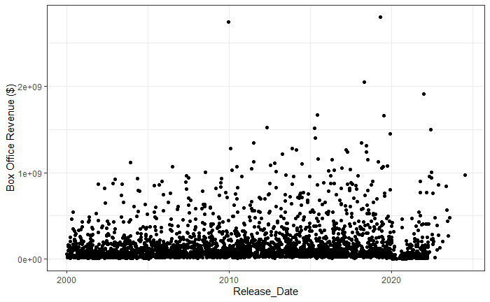

```r
box_office_plot <- box_office_data %>% ggplot(aes(x=Release_Date, y =X.Worldwide)) +
  geom_point() + theme_bw() + ylab('Box Office Revenue ($)')

box_office_plot # display plot
```

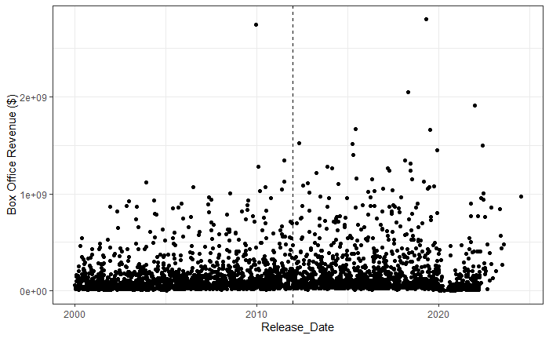

```r
cutpoint<- ymd('2012-01-01') #make a variable storing a date

# Next, add the vertical dashed line at the cutpoint (Jan. 1, 2011):
box_office_plot_cp <- box_office_plot + geom_vline(xintercept = as.numeric(cutpoint), linetype = "dashed")

box_office_plot_cp
```

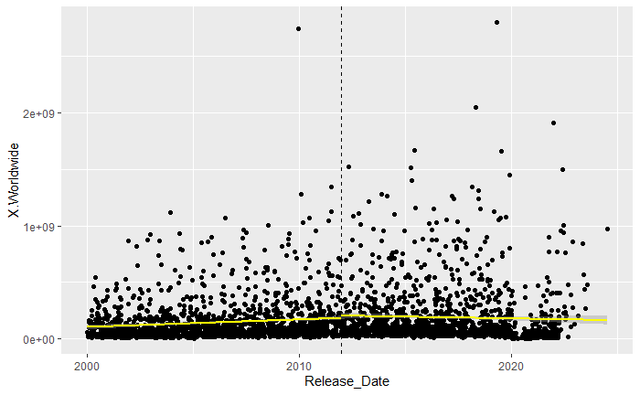

```r
#add column to crash_data in order to create before and after groups relative to the cutpoint
box_office_data_grouped  <- box_office_data %>%  mutate(group = case_when( Release_Date < cutpoint ~ "before", Release_Date >= cutpoint ~ "after_2012"))

#create ggplot
box_office_plot_cp_lm <- box_office_data_grouped %>% ggplot(aes(x=Release_Date, y = X.Worldwide)) +
  geom_point() +
  geom_vline(xintercept = as.numeric(cutpoint), linetype = "dashed") +
  geom_smooth(aes(group = group), color = "yellow", method = lm)

box_office_plot_cp_lm  # display plot
```

The plot shows that there is a slight change in the slope suggesting that perhaps there was an impact from streaming services on the growth of box office revenue, there is also a change in the intercept of the cutpoint, further highlighting this point. As we have chosen to use all the data including during Covid, this may be another reason for the change in slope. In the next section we will calculate the appropriate bandwidth and calculate the change more locally. This will likely remove the effect of the lower revenues of covid.

```r
bandwidths <- (rdbwselect(y=box_office_data$X.Worldwide, x= as.numeric(box_office_data$Release_Date), c = as.numeric(cutpoint)))

bandwidths$bws #show the bandwidths
```

```
      h (left) h (right) b (left) b (right)
mserd 1134.181  1134.181 1709.722  1709.722
```

Bandwidths are added to a variable and then plotted on the original plot.

```r
bw <- bandwidths$bws[1][1]
```

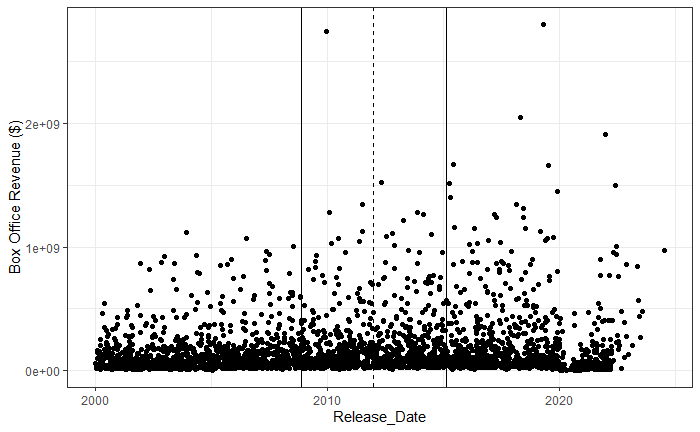

```r
box_office_plot + geom_vline(xintercept = as.numeric(cutpoint), linetype = "dashed") + geom_vline(xintercept = as.numeric(cutpoint) + c(bw, -bw))
```

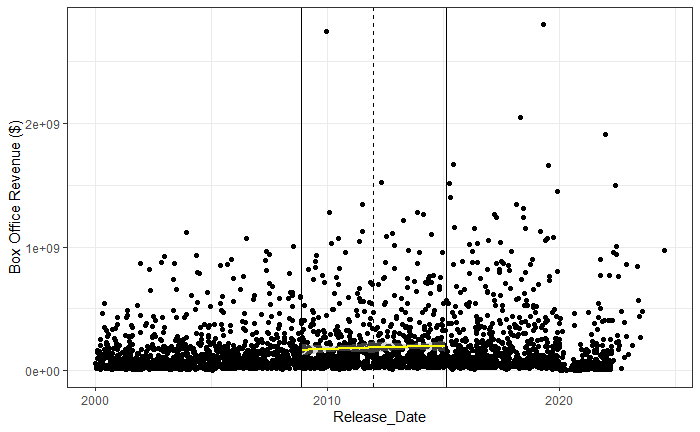

```r
box_office_bw <- box_office_data_grouped %>% filter(as.numeric(Release_Date) > (as.numeric(cutpoint) -bw) & as.numeric(Release_Date) < (as.numeric(cutpoint)+bw))

box_office_plot + geom_vline(xintercept = as.numeric(cutpoint), linetype = "dashed") + geom_vline(xintercept = as.numeric(cutpoint) + c(bw, -bw)) + geom_smooth(data = box_office_bw, aes(x = Release_Date, y = X.Worldwide, group = group), color = 'yellow', method = lm)
```

```r
rda <- rdrobust(y=box_office_data$X.Worldwide, x= as.numeric(box_office_data$Release_Date), c = as.numeric(cutpoint))

print(rda)
```

```
Call: rdrobust

Sharp RD estimates using local polynomial regression.

Number of Obs.                 2883
BW type                       mserd
Kernel                   Triangular
VCE method                       NN

                               Left        Right
Number of Obs.                 1506         1377
Eff. Number of Obs.             422          412
Order est. (p)                    1            1
Order bias (q)                    2            2
BW est. (h)                1134.181     1134.181
BW bias (b)                1709.722     1709.722
rho (h/b)                     0.663        0.663
Unique Obs.                    1107         1000
```

```r
rda$coef
```

```
                 Coeff
Conventional   1844117
Bias-Corrected 1867356
Robust         1867356
```

```r
rda$se
```

```
               Std. Err.
Conventional    33801256
Bias-Corrected  33801256
Robust          40721217
```

```r
rda$pv
```

```
                   P>|z|
Conventional   0.9564909
Bias-Corrected 0.9559432
Robust         0.9634242
```

After calculating the bandwidth and plotting for each bandwidth, there seems to be no statistical difference between ‘pre’ and ‘post’ streaming services becoming popular.

## Conclusion and Next Steps

The analysis shows that based on the available data there was no significant change in the box office revenues pre and post streaming services taking off. This is interesting as many people within the industry are saying that there has been an effect.

While we cannot argue with the outcome of this analysis it is important to recognize any potential floors in this analysis, or other variables which may be affecting the outcome. We have spoken about covid as having a large effect on box office revenue in 2020 and perhaps beyond, however there may have been other events which we have not considered which have had similar effects (either positively or negatively) which we are not aware of or have not considered. Knowing whether this data was completely unaffected by outside variables is both impossible and highly unlikely.

While thinking about this we can consider the assumptions of RDA: 1. The treatment variable impacts the outcome, but not any of the other variables. 2. The treatment assignment happens only at ONE cutpoint value of the forcing variable. 3. Treatment assignment is independent of the potential outcomes within a narrow interval around the cutpoint. 4. Counterfactual outcomes can be modeled within the interval around the cutpoint.

With such a large dataset it hard to be sure we meet these variables. Furthermore with regard to the second assumption, as the use and popularity of streaming services has been increasing since 2011 this may indicate that there is not a clear cutoff point and perhaps fuzzy RDA would have been a better choice for this analysis.

A final point to consider is are there alternative causal analysis methods that could be used which would be more appropriate. This project has been performed as part of my education in data science and therefore my knowledge of other methods may increase in the future to understand how this could be approched better.